# index

## Part 1: Finding Earth-Like Exoplanets

“Two possibilities exist: either we are alone in the Universe or we are not. Both are equally terrifying.” ― Arthur C. Clarke.

For our project we will be working with nasa data because exoplanets are really cool to think about. I mean c'mon, the search for life outside of the solar system is one of the biggest interests of astronomers worldwide Now obviously, it's unlikely that we can really find life with this little project but I think it would be fun to think about how likely it is that we aren't alone in this vast universe.

For our tutorial, we will be taking a human biased perspective, looking for exoplanets which match up the most with our earth, mainly because it is our only current example for the existence of life. We will be using NASA's exoplanet data for convenience. Since there is an option to download a csv directly from their site, we simply have to use pandas to read that csv, keeping in mind to skip the rows which have the column name legend.

```python
import pandas as pd
import seaborn as sns
from matplotlib import pyplot as plt
import numpy as np
from scipy import stats
import statsmodels.api as sm
import statsmodels.formula.api as smf
import csv
from itertools import islice
import math as math

df = pd.read_csv("PSCompPars_2022.11.30_22.37.05.csv",skiprows=88)
df.head()
```

|  | pl_name | hostname | sy_snum | sy_pnum | discoverymethod | disc_year | disc_facility | pl_controv_flag | pl_orbper | pl_orbpererr1 | ... | sy_disterr2 | sy_vmag | sy_vmagerr1 | sy_vmagerr2 | sy_kmag | sy_kmagerr1 | sy_kmagerr2 | sy_gaiamag | sy_gaiamagerr1 | sy_gaiamagerr2 |
| --- | --- | --- | --- | --- | --- | --- | --- | --- | --- | --- | --- | --- | --- | --- | --- | --- | --- | --- | --- | --- | --- |
| 0 | 11 Com b | 11 Com | 2 | 1 | Radial Velocity | 2007 | Xinglong Station | 0 | 326.030000 | 0.320000 | ... | -1.9238 | 4.72307 | 0.023 | -0.023 | 2.282 | 0.346 | -0.346 | 4.44038 | 0.003848 | -0.003848 |
| 1 | 11 UMi b | 11 UMi | 1 | 1 | Radial Velocity | 2009 | Thueringer Landessternwarte Tautenburg | 0 | 516.219970 | 3.200000 | ... | -1.9765 | 5.01300 | 0.005 | -0.005 | 1.939 | 0.270 | -0.270 | 4.56216 | 0.003903 | -0.003903 |
| 2 | 14 And b | 14 And | 1 | 1 | Radial Velocity | 2008 | Okayama Astrophysical Observatory | 0 | 185.840000 | 0.230000 | ... | -0.7140 | 5.23133 | 0.023 | -0.023 | 2.331 | 0.240 | -0.240 | 4.91781 | 0.002826 | -0.002826 |
| 3 | 14 Her b | 14 Her | 1 | 2 | Radial Velocity | 2002 | W. M. Keck Observatory | 0 | 1765.038901 | 1.677089 | ... | -0.0073 | 6.61935 | 0.023 | -0.023 | 4.714 | 0.016 | -0.016 | 6.38300 | 0.000351 | -0.000351 |
| 4 | 16 Cyg B b | 16 Cyg B | 3 | 1 | Radial Velocity | 1996 | Multiple Observatories | 0 | 798.500000 | 1.000000 | ... | -0.0111 | 6.21500 | 0.016 | -0.016 | 4.651 | 0.016 | -0.016 | 6.06428 | 0.000603 | -0.000603 |

5 rows × 84 columns

There are around 84 columns in this dataset, not all of which are going to be useful to us. While you may find some of these for your own twists on this tutorial I will be dropping some of them to make the dataframe less cluttered. By using some built in pandas functionality we can slice out the columns we want to keep.

```python
df = df[['pl_name', 'hostname', 'discoverymethod', 'disc_facility', 'pl_orbper', 'pl_orbsmax', 'pl_bmasse', 'pl_rade', 'st_spectype',
          'st_teff', 'st_mass', 'st_rad']]
df.head()
```

|  | pl_name | hostname | discoverymethod | disc_facility | pl_orbper | pl_orbsmax | pl_bmasse | pl_rade | st_spectype | st_teff | st_mass | st_rad |
| --- | --- | --- | --- | --- | --- | --- | --- | --- | --- | --- | --- | --- |
| 0 | 11 Com b | 11 Com | Radial Velocity | Xinglong Station | 326.030000 | 1.290000 | 6165.60000 | 12.1 | G8 III | 4742.0 | 2.70 | 19.00 |
| 1 | 11 UMi b | 11 UMi | Radial Velocity | Thueringer Landessternwarte Tautenburg | 516.219970 | 1.530000 | 4684.81420 | 12.3 | K4 III | 4213.0 | 2.78 | 29.79 |
| 2 | 14 And b | 14 And | Radial Velocity | Okayama Astrophysical Observatory | 185.840000 | 0.830000 | 1525.50000 | 12.9 | K0 III | 4813.0 | 2.20 | 11.00 |
| 3 | 14 Her b | 14 Her | Radial Velocity | W. M. Keck Observatory | 1765.038901 | 2.773069 | 2586.74645 | 12.6 | K0 V | 5338.0 | 0.91 | 0.93 |
| 4 | 16 Cyg B b | 16 Cyg B | Radial Velocity | Multiple Observatories | 798.500000 | 1.660000 | 565.73740 | 13.5 | G3 V | 5750.0 | 1.08 | 1.13 |

There we go, now our dataframe looks so much nicer. Now that we have these columns it is important to bring up a legend so that we know what they mean. We will be using a DictReader in order to go through NASA's csv file and extract the first few rows, where the legend is. You should have this info available in case you ever have any question about what a column holds.

```python
with open('PSCompPars_2022.11.30_22.37.05.csv') as csvfile:
    reader = csv.DictReader(csvfile)
    for row in islice(reader,2,86): # first few lines
        print(row.values())
```

```
dict_values(['# COLUMN pl_name:        Planet Name'])
dict_values(['# COLUMN hostname:       Host Name'])
dict_values(['# COLUMN sy_snum:        Number of Stars'])
dict_values(['# COLUMN sy_pnum:        Number of Planets'])
dict_values(['# COLUMN discoverymethod: Discovery Method'])
dict_values(['# COLUMN disc_year:      Discovery Year'])
dict_values(['# COLUMN disc_facility:  Discovery Facility'])
dict_values(['# COLUMN pl_controv_flag: Controversial Flag'])
dict_values(['# COLUMN pl_orbper:      Orbital Period [days]'])
dict_values(['# COLUMN pl_orbpererr1:  Orbital Period Upper Unc. [days]'])
dict_values(['# COLUMN pl_orbpererr2:  Orbital Period Lower Unc. [days]'])
dict_values(['# COLUMN pl_orbperlim:   Orbital Period Limit Flag'])
dict_values(['# COLUMN pl_orbsmax:     Orbit Semi-Major Axis [au])'])
dict_values(['# COLUMN pl_orbsmaxerr1: Orbit Semi-Major Axis Upper Unc. [au]'])
dict_values(['# COLUMN pl_orbsmaxerr2: Orbit Semi-Major Axis Lower Unc. [au]'])
dict_values(['# COLUMN pl_orbsmaxlim:  Orbit Semi-Major Axis Limit Flag'])
dict_values(['# COLUMN pl_rade:        Planet Radius [Earth Radius]'])
dict_values(['# COLUMN pl_radeerr1:    Planet Radius Upper Unc. [Earth Radius]'])
dict_values(['# COLUMN pl_radeerr2:    Planet Radius Lower Unc. [Earth Radius]'])
dict_values(['# COLUMN pl_radelim:     Planet Radius Limit Flag'])
dict_values(['# COLUMN pl_radj:        Planet Radius [Jupiter Radius]'])
dict_values(['# COLUMN pl_radjerr1:    Planet Radius Upper Unc. [Jupiter Radius]'])
dict_values(['# COLUMN pl_radjerr2:    Planet Radius Lower Unc. [Jupiter Radius]'])
dict_values(['# COLUMN pl_radjlim:     Planet Radius Limit Flag'])
dict_values(['# COLUMN pl_bmasse:      Planet Mass or Mass*sin(i) [Earth Mass]'])
dict_values(['# COLUMN pl_bmasseerr1:  Planet Mass or Mass*sin(i) [Earth Mass] Upper Unc.'])
dict_values(['# COLUMN pl_bmasseerr2:  Planet Mass or Mass*sin(i) [Earth Mass] Lower Unc.'])
dict_values(['# COLUMN pl_bmasselim:   Planet Mass or Mass*sin(i) [Earth Mass] Limit Flag'])
dict_values(['# COLUMN pl_bmassj:      Planet Mass or Mass*sin(i) [Jupiter Mass]'])
dict_values(['# COLUMN pl_bmassjerr1:  Planet Mass or Mass*sin(i) [Jupiter Mass] Upper Unc.'])
dict_values(['# COLUMN pl_bmassjerr2:  Planet Mass or Mass*sin(i) [Jupiter Mass] Lower Unc.'])
dict_values(['# COLUMN pl_bmassjlim:   Planet Mass or Mass*sin(i) [Jupiter Mass] Limit Flag'])
dict_values(['# COLUMN pl_bmassprov:   Planet Mass or Mass*sin(i) Provenance'])
dict_values(['# COLUMN pl_orbeccen:    Eccentricity'])
dict_values(['# COLUMN pl_orbeccenerr1: Eccentricity Upper Unc.'])
dict_values(['# COLUMN pl_orbeccenerr2: Eccentricity Lower Unc.'])
dict_values(['# COLUMN pl_orbeccenlim: Eccentricity Limit Flag'])
dict_values(['# COLUMN pl_insol:       Insolation Flux [Earth Flux]'])
dict_values(['# COLUMN pl_insolerr1:   Insolation Flux Upper Unc. [Earth Flux]'])
dict_values(['# COLUMN pl_insolerr2:   Insolation Flux Lower Unc. [Earth Flux]'])
```

[output cut: 29 more lines]

```
dict_values(['# COLUMN ra:             RA [deg]'])
dict_values(['# COLUMN decstr:         Dec [sexagesimal]'])
dict_values(['# COLUMN dec:            Dec [deg]'])
dict_values(['# COLUMN sy_dist:        Distance [pc]'])
dict_values(['# COLUMN sy_disterr1:    Distance [pc] Upper Unc'])
dict_values(['# COLUMN sy_disterr2:    Distance [pc] Lower Unc'])
dict_values(['# COLUMN sy_vmag:        V (Johnson) Magnitude'])
dict_values(['# COLUMN sy_vmagerr1:    V (Johnson) Magnitude Upper Unc'])
dict_values(['# COLUMN sy_vmagerr2:    V (Johnson) Magnitude Lower Unc'])
dict_values(['# COLUMN sy_kmag:        Ks (2MASS) Magnitude'])
dict_values(['# COLUMN sy_kmagerr1:    Ks (2MASS) Magnitude Upper Unc'])
dict_values(['# COLUMN sy_kmagerr2:    Ks (2MASS) Magnitude Lower Unc'])
dict_values(['# COLUMN sy_gaiamag:     Gaia Magnitude'])
dict_values(['# COLUMN sy_gaiamagerr1: Gaia Magnitude Upper Unc'])
dict_values(['# COLUMN sy_gaiamagerr2: Gaia Magnitude Lower Unc'])
```

Our sun is a G2 class star, often referred to as a yellow dwarf. This classification can tell us a lot about a star but for now what we care about is that it tells us a star is similar to our sun. We will filter our data by looking at any star which is a G2 class as well. Due to this being a substring, on top of the usual filtering we have to cast the column contents as a string in order to use the contains method.

```python
G2 = df.dropna(subset=['st_spectype'])
G2 = G2[G2['st_spectype'].str.contains("G2")]
G2.head()
```

|  | pl_name | hostname | discoverymethod | disc_facility | pl_orbper | pl_orbsmax | pl_bmasse | pl_rade | st_spectype | st_teff | st_mass | st_rad |
| --- | --- | --- | --- | --- | --- | --- | --- | --- | --- | --- | --- | --- |
| 86 | CoRoT-17 b | CoRoT-17 | Transit | CoRoT | 3.76810 | 0.0461 | 772.2900 | 11.430 | G2 V | 5740.0 | 1.04 | 1.59 |
| 90 | CoRoT-20 b | CoRoT-20 | Transit | CoRoT | 9.24285 | 0.0900 | 1366.6690 | 9.416 | G2 V | 5880.0 | 1.14 | 1.02 |
| 91 | CoRoT-20 c | CoRoT-20 | Radial Velocity | Multiple Observatories | 1675.00000 | 2.9000 | 5403.1100 | 12.200 | G2 V | 4947.5 | 1.14 | 1.37 |
| 99 | CoRoT-27 b | CoRoT-27 | Transit | CoRoT | 3.57532 | 0.0476 | 3302.1100 | 11.287 | G2 | 5900.0 | 1.05 | 1.08 |
| 104 | CoRoT-31 b | CoRoT-31 | Transit | CoRoT | 4.62941 | 0.0586 | 266.9772 | 16.365 | G2 IV | 5700.0 | 1.25 | 2.15 |

Arguably the most important factor for finding earth-like and just habitable planets is its location within the habitable zone. The habitable zone is an area beginning and ending some distance away from a star in which for the most part, water can exist in a liquid form. Liquid water is vital to life as we know it as it serves as a medium for chemical reactions to occur in, more complex compounds to form, among other things. We will be using three new rows for our purposes. HZinner and HZouter will be used to store the inner and outer reach of the habitable zone. Using a simple logical check we will also see if the planet's orbit falls within the habitable zone. Fortunately for us NASA has an equation to find the inner and outer range of the habitable zone for G2 stars.

```python
G2['HZinner'] = np.nan
G2['HZouter'] = np.nan
G2['habitable'] = 1
for i, row in (G2.iterrows()):
    G2.at[i,'HZinner'] = 0.75*math.sqrt(G2.at[i,'st_rad']**2 * (G2.at[i,'st_teff']/5780)**4) #calculating the bounds
    G2.at[i,'HZouter'] = 1.77*math.sqrt(G2.at[i,'st_rad']**2 * (G2.at[i,'st_teff']/5780)**4)
    if (G2.at[i,'pl_orbsmax'] < G2.at[i,'HZinner']) or (G2.at[i,'pl_orbsmax'] > G2.at[i,'HZouter']): #checking if the planet falls within
        G2.at[i,'habitable'] = 0
```

```python
G2 = G2[G2['habitable'] == 1]
G2
```

|  | pl_name | hostname | discoverymethod | disc_facility | pl_orbper | pl_orbsmax | pl_bmasse | pl_rade | st_spectype | st_teff | st_mass | st_rad | HZinner | HZouter | habitable |
| --- | --- | --- | --- | --- | --- | --- | --- | --- | --- | --- | --- | --- | --- | --- | --- |
| 570 | HD 133131 A b | HD 133131 A | Radial Velocity | Las Campanas Observatory | 649.000000 | 1.440000 | 451.31860 | 13.600 | G2 V | 5799.0 | 0.95 | 0.96 | 0.724741 | 1.710390 | 1 |
| 603 | HD 141937 b | HD 141937 | Radial Velocity | La Silla Observatory | 653.219970 | 1.500000 | 3079.77270 | 12.500 | G2/G3 V | 5870.0 | 1.09 | 1.03 | 0.796744 | 1.880317 | 1 |
| 743 | HD 183263 b | HD 183263 | Radial Velocity | W. M. Keck Observatory | 624.874039 | 1.459291 | 1102.03602 | 13.100 | G2 IV | 5948.0 | 1.06 | 1.23 | 0.976906 | 2.305497 | 1 |
| 799 | HD 2039 b | HD 2039 | Radial Velocity | Anglo-Australian Telescope | 1120.000000 | 2.200000 | 1999.15070 | 12.700 | G2/G3 IV/V | 5945.0 | 1.23 | 1.19 | 0.944183 | 2.228272 | 1 |
| 848 | HD 216437 b | HD 216437 | Radial Velocity | Anglo-Australian Telescope | 1334.280000 | 2.497000 | 706.53609 | 13.300 | G2/3IV | 5909.0 | 1.17 | 1.39 | 1.089553 | 2.571345 | 1 |
| 893 | HD 23127 b | HD 23127 | Radial Velocity | Anglo-Australian Telescope | 1211.170000 | 2.370000 | 485.32641 | 13.500 | G2 V | 5843.0 | 1.21 | 1.49 | 1.141993 | 2.695105 | 1 |
| 1012 | HD 44219 b | HD 44219 | Radial Velocity | La Silla Observatory | 472.300000 | 1.190000 | 184.33000 | 14.100 | G2 V | 5752.0 | 1.00 | 1.32 | 0.980432 | 2.313818 | 1 |
| 1045 | HD 564 b | HD 564 | Radial Velocity | La Silla Observatory | 492.300000 | 1.200000 | 104.88000 | 12.500 | G2/G3 V | 5902.0 | 0.96 | 1.01 | 0.789815 | 1.863963 | 1 |
| 1120 | HD 82943 b | HD 82943 | Radial Velocity | La Silla Observatory | 441.470000 | 1.183060 | 534.25000 | 13.500 | G2/3V | 5935.0 | 1.08 | 1.18 | 0.933102 | 2.202120 | 1 |
| 1648 | K2-398 b | K2-398 | Transit | K2 | 6.393025 | NaN | 5.79000 | 2.274 | G2 | 5946.0 | 0.95 | 1.24 | 0.984186 | 2.322678 | 1 |
| 1649 | K2-398 c | K2-398 | Transit | K2 | 18.787839 | NaN | 22.80000 | 5.098 | G2 | 5946.0 | 0.95 | 1.24 | 0.984186 | 2.322678 | 1 |
| 1654 | K2-402 b | K2-402 | Transit | K2 | 17.274740 | NaN | 7.65000 | 2.678 | G2 | 5716.0 | 0.94 | 1.28 | 0.938858 | 2.215705 | 1 |
| 3804 | Kepler-452 b | Kepler-452 | Transit | Kepler | 384.843000 | 1.046000 | 3.29000 | 1.630 | G2 | 5757.0 | 1.04 | 1.11 | 0.825888 | 1.949095 | 1 |
| 4990 | WASP-126 c | WASP-126 | Transit Timing Variations | Transiting Exoplanet Survey Satellite (TESS) | 7.630000 | NaN | 64.20000 | 9.380 | G2 | 5800.0 | 1.12 | 1.27 | 0.959103 | 2.263483 | 1 |

Now that we've filtered out the planets which lie within the range of the habitable zone, we have to do additional filtering to curate Earth-like planets. According to NASA, one factor of being considered an Earth-like planet is its size, typically looking for a planetary radius of 0.5 to 2.0 of earth radii.

```python
G2 = G2[G2['pl_rade']<=2.0]
G2 = G2[G2['pl_rade']>=0.5]
G2
```

|  | pl_name | hostname | discoverymethod | disc_facility | pl_orbper | pl_orbsmax | pl_bmasse | pl_rade | st_spectype | st_teff | st_mass | st_rad | HZinner | HZouter | habitable |
| --- | --- | --- | --- | --- | --- | --- | --- | --- | --- | --- | --- | --- | --- | --- | --- |
| 3804 | Kepler-452 b | Kepler-452 | Transit | Kepler | 384.843 | 1.046 | 3.29 | 1.63 | G2 | 5757.0 | 1.04 | 1.11 | 0.825888 | 1.949095 | 1 |

Another factor we look for in Earth like planets is their mass. Since planet mass determines gravity, and we need to exist within a fairly limited range of gravity for our biology to kep functioning, planet mass faces a slightly small range of acceptable values.

```python
G2 = G2[G2['pl_bmasse']<=1.9]
G2 = G2[G2['pl_bmasse']>=0.8]
G2
```

|  | pl_name | hostname | discoverymethod | disc_facility | pl_orbper | pl_orbsmax | pl_bmasse | pl_rade | st_spectype | st_teff | st_mass | st_rad | HZinner | HZouter | habitable |
| --- | --- | --- | --- | --- | --- | --- | --- | --- | --- | --- | --- | --- | --- | --- | --- |

This does not particularly give us a lot to work with. Such issues can easily arise whenever you are looking into an incredibly specific subset of the data. As such we will have to broaden our horizons and try again.

## Part 2: Lowering our standards

So clearly taking a very earth centered approach is not the way to go. But even if we go to the absolute limits of what can be considered habitable it would still be difficult to concretely state that a planet was habitable due to the amount of factors which play into the equation, a lot of which we simply do not know. We can however account for as many factors as possible given the data, and for the sake of our experiment, take on the most optimistic view possible.

Beginning our analysis, we first have to talk about main sequence stars. 90% of the stars in our universe are main sequence stars, meaning they fuse hydrogen to form helium, like our sun does. Studying these main sequence stars astronomers managed to come to the conclusion that a main sequence stars' temperature, color, and luminosity are all related. All of these variables play a role in our calculation of the habitable zone and as such are of great interest to us.

For right now, I want to see the spread of discovered exoplanets across varying stars. And in general scrape together more info about them.

```python
df['st_spectype'].unique()
```

```
array(['G8 III', 'K4 III', 'K0 III', 'K0 V', 'G3 V', 'K3 III', 'G6 III',
       'K7 V', 'G3 IV', 'K0 IV', 'M V', 'M5.5/M6', 'M3.5 V', 'M6', 'M8.5',
       'M8', nan, 'F6 V', 'K1 III', 'K1.5 III', 'G0 V', 'G1 V', 'G0V',
       'F0 IV', 'G5V', 'K0 IV-V', 'G8V', 'G8 V', 'G5 V', 'K1III(+M)',
       'G3 III', 'K0', 'G5 III', 'K2 V', 'M1', 'G5', 'K2 II', 'K5 III',
       'G', 'K1', 'K3', 'G0', 'K7/M0 V', 'K3 V', 'K7V', 'G5 IV/V', 'K5 V',
       'M5.0 V', 'M9-L1', 'M3.5', 'K7', 'M3 V', 'K5e', 'K1 V', 'F9 V',
       'G2 V', 'G9 V', 'F8 IV', 'F9', 'G2', 'G8/9 IV', 'F3 V', 'G2 IV',
       'G0 VI', 'L1.5', 'M0.5', 'F8 V', 'F5 V', 'G6 V', 'M0', 'G8 IV/V',
       'M7.25', 'M4.0 V', 'M2.5 V', 'M5.5 V', 'M4.5 V', 'M5', 'M4 V',
       'M3', 'K4.5', 'M0 V', 'M', 'M2 V', 'M0V:', 'M1.5V', 'M1/M2 V',
       'M3.0 V', 'M0.5 V', 'M4', 'K0V', 'M2.5', 'M0.0 V', 'M1.5',
       'M1.0 V', 'M2.0 V', 'M1.5 V', 'M4.0', 'M2V', 'M3.5 Ve',
       'M0.5-1.0 V', 'M1 V', 'M2', 'K5', 'M3.0V', 'K1V', 'M2.5V', 'K5V',
       'K6 V', 'F2', 'K7e V', 'K4', 'G4', 'F8', 'K', 'K2', 'G3', 'G8',
       'F7', 'F4', 'F', 'F5', 'G7', 'A8 V', 'F6', 'G V', 'K V', 'F V',
       'B9 Vne', 'G9 III', 'G3/5V', 'K1 V(P)', 'G5 IV', 'F8 V CH+0.4',
       'G4 V', 'K2 III', 'G6/8 V', 'K2 III/IV', 'K9 V', 'K3V', 'G4 IV',
       'K2V', 'G9 V CN+1', 'G8 III/IV', 'G7 III', 'G7 V', 'K4 V', 'G8 IV',
       'K2 IV', 'G5 III/IV', 'G6IV', 'G0Vvar', 'G2/G3 V', 'F7V', 'G1 IV',
       'G0/2 V', 'K0 III/IV', 'G2V', 'G6', 'F8 IV/V', 'K1 IV', 'G3 IV-V',
       'K3.5 V', 'F7 V', 'K2.5 V', 'G6 IV', 'K3 IV', 'K0 III-IV', 'G0 IV',
       'G8/K0 IV', 'K3/4V', 'G3V', 'G2/G3 IV/V', 'K1/2V', 'G1.5 V',
       'M1 III', 'K3/4 IV', 'G0/1 V', 'G2/3IV', 'M2 III', 'K0 IV/V',
       'F9 IV/V', 'K5/M0V', 'F9.5 V', 'K1/2III', 'F8/G0 V', 'G1 IV/V',
       'K4.5 V', 'G3/G5 V', 'K1/K2 V', 'G7 V Fe-1 CH-0.5', 'G8/K0',
       'K1 IV-V', 'F6 IV', 'K0IIIvar', 'G5IV', 'G8/K0 III', 'G2/3 V',
       'G8 IV (+ G)', 'G1-1.5 V', 'K0.5 V', 'G2/G3', 'G2/3V', 'K1.5 V',
       'A8 III', 'Be9.5/AO', 'M0.5 Ve', 'A2 V', 'B9 V', 'A5 V', 'A5',
       'M2.5e', 'F9 IV', 'K5.5', 'M0.0', 'G9', 'G7 IV/V',
       'M0.0&plusmn0.5 V', 'M(3.5+/-0.5) V', 'M3.3', 'G1', 'K7.5 V',
       'M3.0', 'A', 'F4 V', 'B9.5-A0', 'B', 'M2.0V', 'F5 IV', 'G9/K0',
       'm3 V', 'M(6.1+/-0.7) V', 'M6 V', 'A8', 'A7 V', 'WD', 'M9',
       'K9 V/M0 V', 'M4.5V-M5V', 'K1-K2', 'Am C', 'M4 &#177 0.5 V', 'F0',
       'G9 IV', 'M5V', 'M1.0', 'K8 V', 'F7/F8V', 'G0/F9 V', 'M7.0 V',
       'M7', 'sdBV', 'M7.5', 'K6', 'F1 V', 'A1 IV-V', 'F6 IV-V',
       'K7-M0 V', 'DQ', 'T8.5', 'F5V', 'K2III', 'B2.5 V', 'A5V',
       'K1 IIIb Fe-0.5', 'B9 IV', 'B2 IV', 'G8.5V'], dtype=object)
```

There are a lot of unique types and subtypes which we might have to worry about if we end up doing a more in depth analysis at some point. For now, I will just be looking at the base class of each star for simplicity. I will do this by adding a new column which will assign a color to each main class for grouping, and also for ease of coloration when we begin plotting. We will also be extracting the main class of the star, and also performing the luminosity calculation in advance as it will be useful to us down the line.

```python
df = df.dropna(subset=['st_rad', 'st_teff', 'st_spectype', 'pl_orbsmax']) #we can't do calculations with missing variables
#and mean imputation would not work as star systems can vary pretty significantly from the mean
df['main_cat'] = 'na'
df['main_color'] = 'w'
df['luminosity'] = 0.0 #don't forget to set this to a float
for i, row in (df.iterrows()):
    if "O" in str(df.at[i,'st_spectype'])[0]: #depending on the main type we assign a color
        df.at[i,'main_color'] = "b"
    if "B" in str(df.at[i,'st_spectype'])[0]:
        df.at[i,'main_color'] = "royalblue"
    if "A" in str(df.at[i,'st_spectype'])[0]:
        df.at[i,'main_color'] = "lightskyblue"
    if "F" in str(df.at[i,'st_spectype'])[0]:
        df.at[i,'main_color'] = "lightgray"
    if "G" in str(df.at[i,'st_spectype'])[0]:
        df.at[i,'main_color'] = "yellow"
    if "K" in str(df.at[i,'st_spectype'])[0]:
        df.at[i,'main_color'] = "tab:orange"
    if "M" in str(df.at[i,'st_spectype'])[0]:
        df.at[i,'main_color'] = "r"
    df.at[i,'luminosity'] = df.at[i,'st_rad']**2 * (df.at[i,'st_teff']/5780)**4 #here we introduce another variable, luminosity
    #it will be nice to have this available for habitable zone calculations in the future
    df.at[i,'main_type'] = str(df.at[i,'st_spectype'])[0].upper() #Extracts the main type of a star
df['main_type'].unique()
```

```
array(['G', 'K', 'M', 'F', 'A', 'B', 'S', 'T'], dtype=object)
```

There are a few stars which do not fall into the main sequence, and as such we will be getting rid of them for our first visualization. Additionally we will be categorizing the main star class for sorting purposes.

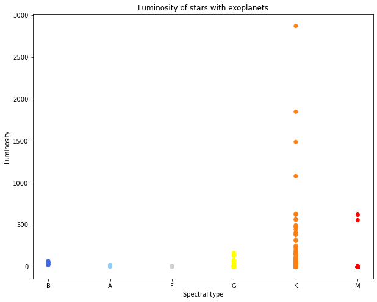

```python
df = df[df['main_type'] != 'S']
df = df[df['main_type'] != 'T']
cats = ['B','A','F','G','K','M']
df['main_type'] = pd.CategoricalIndex(df['main_type'], ordered=True, categories=cats) #sets the main types into categories
df = df.sort_values('main_type') #and sorts the categories into the typical main sequence ordering
plt.rcParams['figure.figsize'] = [10, 8]

bright_lim = df[df['luminosity']<5000] #some outlier values have been ommited for vizualization purposes
plt.scatter('main_type', 'luminosity', c='main_color', data=bright_lim)
plt.xlabel('Spectral type')
plt.ylabel('Luminosity')
plt.title('Luminosity of stars with exoplanets')
plt.show()
```

Notice that most luminosities are very low with a notable outlier B class star being omitted for this visualization, and a lot more variety with G, K, and M class stars. That is because if a star is incredibly bright it is harder to spot when an exoplanet passes in front of it. Not only that but there are no documented O class stars with exoplanets in this dataset. That's because these stars are typically very bright and massive, so our typical techniques of seeing how orbiting planets make a star wobble are also not as effective. K and M class stars are the two most common main sequence stars which is why we see a lot more results there. We see a lot of results for K class stars because they are of particular interest to NASA. These stars last a very long time, giving life a good chance to develop. Their chemical composition also makes it a bit more likely for oxygen and methane traces to be discovered, which can contribute to the possible presence of ozones and free oxygen within the atmospheres of exoplanets. You can read more about that here: https://www.nasa.gov/feature/goddard/2019/k-star-advantage

Next up I want to look at exoplanets and their distances from their host stars by spectral class. Knowing the general luminosities of these stars we also want to see how far away planets typically orbit their stars, which can give us the general distribution of planets around their host stars. I also want to take a look at planet masses since this will also play into our computations later on.

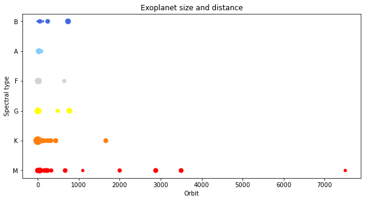

```python
size_lim = df[df['pl_rade']<50] #in order to get a better look at the data I will be filtering out certain entries

plt.figure(figsize=(10,5))
plt.scatter('pl_orbsmax', 'main_type', c='main_color', s = size_lim['pl_bmasse']/100, data=size_lim)
plt.gca().invert_yaxis()
plt.xlabel('Orbit')
plt.ylabel('Spectral type')
plt.title('Exoplanet size and distance')
plt.show()
```

Looking at this graph there are a few things to note. A lot of these planets are concentrated within just a few astronomical units (the distance between our sun and the Earth) of their host star, though there are plenty of planets which lie further out. This is expected as the previously mentioned methods of detecting exoplanets work much better on less distant exoplanets. It also appears that most of these exoplanets have fairly similar masses, with a massive outlier the size of multiple earths being excluded around a B class star. As previously mentioned the planets we have discovered tend to be either close to the star or much larger. In order to get a better understanding we should take a look at exoplanet size and masses.

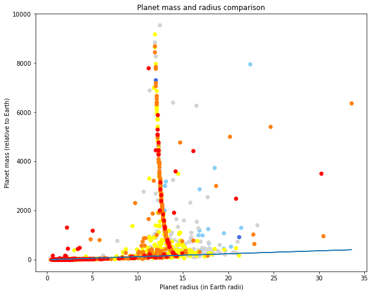

```python
size_lim = df[df['pl_rade']<50] #in order to get a better look at the data I will be filtering out certain entries
size_lim = size_lim[size_lim['pl_bmasse']<10000]
#a, b = np.polyfit(size_lim['pl_rade'], size_lim['pl_bmasse'], deg=1)

plt.rcParams['figure.figsize'] = [10, 8]
plt.scatter('pl_rade', 'pl_bmasse', c='main_color', data=size_lim)
plt.plot(size_lim['pl_rade'], 12*size_lim['pl_rade'])
plt.xlabel('Planet radius (in Earth radii)')
plt.ylabel('Planet mass (relative to Earth)')
plt.title('Planet mass and radius comparison')
plt.show()
```

In addition to the visualizations we should get numerical representations of the exoplanets we will be dealing with for good measure. For this we will be grouping by the main type, and then getting the medians of the exoplanet radii, masses, and orbits. The reason I am going for the median is because the mean is highly sensitive to outliers of which this data possesses a good amount of.

```python
print(df.groupby('main_type', as_index=False)[['pl_rade','pl_bmasse','pl_orbsmax']].median())
```

```
  main_type  pl_rade    pl_bmasse  pl_orbsmax
0         B   12.300  2621.355200   54.000000
1         A   17.094  1293.568100    0.063700
2         F   13.600   387.752600    0.066400
3         G   12.600   261.604875    0.248500
4         K   11.902   191.174745    0.247805
5         M    2.205     6.260000    0.071200
```

One running pattern that we see here is that exoplanets around M class stars are typically smaller than exoplanets from other stars, and possess fairly orbits. We see that exoplanets around B and A class stars typically have significantly larger masses than other counterparts, though it could be a result of detection bias from the methods we use to find them. A lot of B class stars tend to have exoplanets with distant orbits, and as such I do not expect us to see many habitable exoplanets from B class stars, if any. Exoplanets around M class stars having small radii and masses is consistent with the previous visualization.

## Now for potentially habitable exoplanets

As previously mentioned, arguably the most important factor to deciding if a planet is potentially habitable is an orbit that falls within the habitable zone. In reality, it's impossible to express the habitable zone in a single equation due to the amount of factors at play ranging from the planet's atmosphere to the type of star it orbits. But for the sake of our model we will be simplifying the calculation down significantly, using the findings from this research paper: https://arxiv.org/abs/1301.6674

```python
df['HZinner'] = np.nan
df['HZouter'] = np.nan
df['habitable'] = 1
for i, row in (df.iterrows()):
    df.at[i,'HZinner'] = 0.65*math.sqrt(df.at[i,'luminosity'])
    df.at[i,'HZouter'] = 1.57*math.sqrt(df.at[i,'luminosity'])
    if (df.at[i,'pl_orbsmax'] < df.at[i,'HZinner']) or (df.at[i,'pl_orbsmax'] > df.at[i,'HZouter']):
        df.at[i,'habitable'] = 0
```

```python
df[df['habitable'] == 1]
```

|  | pl_name | hostname | discoverymethod | disc_facility | pl_orbper | pl_orbsmax | pl_bmasse | pl_rade | st_spectype | st_teff | st_mass | st_rad | main_cat | main_color | luminosity | main_type | HZinner | HZouter | habitable |
| --- | --- | --- | --- | --- | --- | --- | --- | --- | --- | --- | --- | --- | --- | --- | --- | --- | --- | --- | --- |
| 5173 | bet Pic c | bet Pic | Radial Velocity | La Silla Observatory | 1192.779510 | 2.680483 | 3223.13586 | 12.500 | A5V | 7890.00 | 1.80 | 2.01 | na | lightskyblue | 14.027774 | A | 2.434489 | 5.880226 | 1 |
| 663 | HD 156411 b | HD 156411 | Radial Velocity | La Silla Observatory | 842.200000 | 1.880000 | 235.18000 | 14.000 | F8 IV/V | 5900.00 | 1.25 | 2.16 | na | lightgray | 5.065289 | F | 1.462903 | 3.533473 | 1 |
| 647 | HD 153950 b | HD 153950 | Radial Velocity | La Silla Observatory | 499.399990 | 1.280000 | 937.59850 | 13.200 | F8 V | 6124.00 | 1.25 | 1.28 | na | lightgray | 2.064664 | F | 0.933981 | 2.255923 | 1 |
| 945 | HD 30562 b | HD 30562 | Radial Velocity | Lick Observatory | 1157.000000 | 2.340000 | 387.75260 | 13.700 | F8 V | 5882.00 | 1.12 | 1.61 | na | lightgray | 2.779972 | F | 1.083761 | 2.617700 | 1 |
| 710 | HD 169830 c | HD 169830 | Radial Velocity | La Silla Observatory | 1818.823393 | 3.073402 | 2259.86363 | 12.700 | F8 V | 6179.26 | 1.17 | 1.94 | na | lightgray | 4.916296 | F | 1.441227 | 3.481117 | 1 |
| ... | ... | ... | ... | ... | ... | ... | ... | ... | ... | ... | ... | ... | ... | ... | ... | ... | ... | ... | ... |
| 4781 | TOI-1452 b | TOI-1452 | Transit | Transiting Exoplanet Survey Satellite (TESS) | 11.062010 | 0.061000 | 4.82000 | 1.672 | M4 &#177 0.5 V | 3185.00 | 0.25 | 0.28 | na | r | 0.007228 | M | 0.055263 | 0.133481 | 1 |
| 4840 | TOI-2257 b | TOI-2257 | Transit | Transiting Exoplanet Survey Satellite (TESS) | 35.189346 | 0.145000 | 5.45000 | 2.194 | M3 | 3430.00 | 0.33 | 0.31 | na | r | 0.011918 | M | 0.070959 | 0.171393 | 1 |
| 3790 | Kepler-445 d | Kepler-445 | Transit | Kepler | 8.152750 | 0.043900 | 2.10000 | 1.250 | M4 | 3157.00 | 0.18 | 0.21 | na | r | 0.003925 | M | 0.040722 | 0.098359 | 1 |
| 223 | GJ 3473 c | GJ 3473 | Radial Velocity | Multiple Observatories | 15.509000 | 0.087600 | 7.41000 | 2.630 | M4 | 3347.00 | 0.36 | 0.36 | na | r | 0.014572 | M | 0.078464 | 0.189521 | 1 |
| 4947 | Teegarden's Star b | Teegarden's Star | Radial Velocity | Calar Alto Observatory | 4.910000 | 0.025200 | 1.05000 | 1.020 | M7.0 V | 2904.00 | 0.09 | 0.11 | na | r | 0.000771 | M | 0.018049 | 0.043594 | 1 |

186 rows × 19 columns

Here are all of the planets that fall within the parameters we have set for the habitable zone. It's important to remember that while these planets fall within the habitable zone they aren't necessarily habitable. A planet that is more similar to Jupiter or Neptune rather than our earth would not be habitable, at least given our current understanding of life. As such, we need to classify potentially terrestrial planets since they are, from our understanding, most likely to be habitable: https://phl.upr.edu/projects/habitable-exoplanets-catalog

```python
df['planet_type'] = 'Other' #we can add colors and plot of needed
for i, row in (df.iterrows()):
    if 0.1 <= df.at[i,'pl_bmasse'] <= 0.5 and 0.4 <= df.at[i,'pl_rade'] <= 0.8:
        df.at[i,'planet_type'] = 'Subterran' #about mars sized
    if 0.5 <= df.at[i,'pl_bmasse'] <= 3 and 0.8 <= df.at[i,'pl_rade'] <= 1.6:
        df.at[i,'planet_type'] = 'Terran' #about earth sized
    if 3 <= df.at[i,'pl_bmasse'] <= 10 and 1.6 <= df.at[i,'pl_rade'] <= 2.5:
        df.at[i,'planet_type'] = 'Superterran' #super earth sized
df[df['habitable'] == 1]['planet_type'].value_counts()
```

```
Other          149
Superterran     23
Terran          14
Name: planet_type, dtype: int64
```

It seems that we have only found Earth-like planets and Super Earths within their star's habitable zones. Again this makes sense because larger planets are easier to detect. Going down from over 5000 potentially habitable planets to less than 50 really puts into perspective how hard it is for life to exist. To get one last good look at the data let's make another visualization showcasing luminosity and planet orbits.

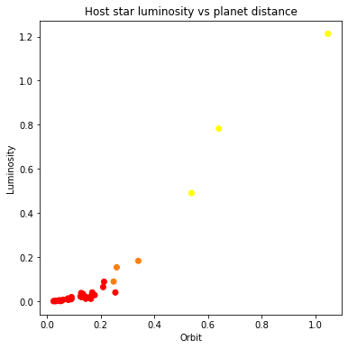

```python
terra = df[df['habitable'] == 1]
terra = terra[terra['planet_type']!='Other'] #only looking at terran planets

plt.figure(figsize=(6,6))
plt.scatter('pl_orbsmax', 'luminosity', c='main_color', data=terra)
plt.xlabel('Orbit')
plt.ylabel('Luminosity')
plt.title('Host star luminosity vs planet distance')
plt.show()
```

This is such a nice pattern. As you can see the less luminous a star is the closer a planet has to be in the habitable zone, and in general there is a positive correlation between luminosity and distance from the star. We also see that all of these planets are from G, K, and M stars. These are the stars which are typically dimmer as seen here, and also tend to burn longer, which gives life a better chance to develop. It would also be nice to see how these exoplanets compare to our Earth, so let's make a visualization invlolving planet orbits, masses, and radii.

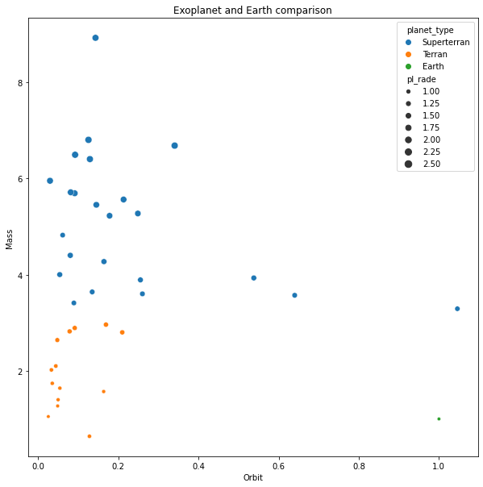

```python
plt.figure(figsize=(10,10))
empty = pd.DataFrame([[np.nan] * len(terra.columns)], columns=terra.columns)
terra = terra.append(empty, ignore_index=True) #create an extra row for the Earth
terra.at[len(terra)-1,'pl_orbsmax'] = 1
terra.at[len(terra)-1,'pl_bmasse'] = 1 #since evrything else is easured in earth values these are all 1
terra.at[len(terra)-1,'pl_rade'] = 1
terra.at[len(terra)-1,'planet_type'] = 'Earth' #for coloration and to clarify this is not an exoplanet
sns.scatterplot(data=terra,x='pl_orbsmax', y='pl_bmasse', hue='planet_type', size='pl_rade')
plt.xlabel('Orbit')
plt.ylabel('Mass')
plt.title('Exoplanet and Earth comparison')
plt.show()
```

Looking at these exoplanets there are a few things we can now make out more clearly. Most of these planets are located fairly close to their host stars, which makes sense given how many low luminosity stars were shown in the previous visualization. We can see a divide between Terran and Super terran planets in terms of both radius and mass, and earth falls within the Terran category on both accounts. Since most of the stars these exoplanets were orbiting ended up being K and M class stars it does make sense that these planets are different, with the three exoplanets orbiting further than 0.4 au away from their stars being the ones around the G class stars, which is why they are a bit closer to Earth's orbit.

Next up I want to set up a decision tree classifier on the data we have so far to see how it compares to the data we got manually. We will be importing a few additional libraries, and will also be setting our habitable planets to terrestrial planets in the habitable zone. Since the calculations we used to get these planets are fairly simple, I think our model will have a reasonably high accuracy. I will be training it on just the basic variables used in our calculations of habitable terran planets.

```python
from sklearn.model_selection import train_test_split
from sklearn.linear_model import LinearRegression
from sklearn.metrics import mean_squared_error, mean_absolute_error
from sklearn import preprocessing
from sklearn.metrics import accuracy_score
from sklearn.tree import DecisionTreeClassifier # Import Decision Tree Classifier
from sklearn import tree
```

```python
df['target'] = 0
for i, row in (df.iterrows()):
    if df.at[i,'planet_type'] != 'Other' and df.at[i,'habitable'] == 1:
        df.at[i,'target'] = 1

data = df[['luminosity', 'pl_orbsmax', 'pl_bmasse', 'pl_rade', 'target']].dropna()

X = data[['luminosity', 'pl_orbsmax', 'pl_bmasse', 'pl_rade']] #independent variables
y = data['target']

X_train, X_test, y_train, y_test = train_test_split(X, y, test_size=0.2, random_state=101) #creating the test and train split

clf = DecisionTreeClassifier(max_depth=3) #our decision tree classifier

model = clf.fit(X_train,y_train) #fitting the model

predictions = model.predict(X_test) #and then training it

print("Test data accuracy:",accuracy_score(y_true = y_test, y_pred=predictions)) #and our accuracy
text_representation = tree.export_text(clf, feature_names = list(X.columns)) #putting our tree into a text vizualization
print(text_representation)
```

```
Test data accuracy: 0.9884726224783862
|--- luminosity <= 0.04
|   |--- pl_rade <= 2.50
|   |   |--- pl_orbsmax <= 0.12
|   |   |   |--- class: 0
|   |   |--- pl_orbsmax >  0.12
|   |   |   |--- class: 1
|   |--- pl_rade >  2.50
|   |   |--- class: 0
|--- luminosity >  0.04
|   |--- pl_bmasse <= 6.69
|   |   |--- pl_orbsmax <= 0.21
|   |   |   |--- class: 0
|   |   |--- pl_orbsmax >  0.21
|   |   |   |--- class: 0
|   |--- pl_bmasse >  6.69
|   |   |--- class: 0
```

One other equation which I want to take a look at before we wrap up is the Drake equation. This equation is a theoretical prediction of the number of advanced extraterrestrial civilizations with the technology to reach out to us. Initially made to stir up dialogue during some of the first SETI meetings, it acts as a fairly good summary of some of the factors we need to consider in our search for extraterrestrial intelligent life. One of the factors in this equation is the average number of planets that can potentially support life per star that has planets. So we will be comparing our results using the habitable planet data we got to a relatively optimistic calculation.

```python
N_drake = 1.5 * 1 * 0.4 * 0.5 * 0.5 * 0.5 * 420.6 #average number of planets that can potentially support life is 0.4 here
Our_drake = 1.5 * 1 * df['target'].sum()/len(df['target']) * 0.5 * 0.5 * 0.5 * 420.6
print("Opimistic number of intelligent civilizations", N_drake)
print("Our approximated number of intelligent civilizations", Our_drake)

n_array = np.zeros(len(df.target))
n_array[:696] = 1 #the mean of this array is the same as the value used in the optimistic calculation
                  #we do this to make the ttest work as intended
stats.ttest_ind(a=df['target'], b=n_array, equal_var=True)
```

```
Opimistic number of intelligent civilizations 31.545000000000005
Our approximated number of intelligent civilizations 1.6788909666283087
```

```
Ttest_indResult(statistic=-30.93681848126587, pvalue=7.88681329467399e-186)
```

Looking at these two calculations we can see that the results we got using our calculations result in a much lower count of potentially intelligent life in our galaxy, going from over 30 intelligent civilizations, to around 1. Seeing how small the p value is it's safe to say that our calculations are significantly different from the optimistic calculation. For now we don't know enough about the galaxy to say which calculation is closer to the truth, so there's no right or wrong calculation per say. If we ever do start finding intelligent civilizations we will be able to revisit this calculation with a new perspective.

# Conclusion

Though this analysis went well it's important to keep in mind that the info we got here is very likely to change in the future. Life on moons such as Europa could be confirmed, which would expand the range of planets we would be interested in. Analysis of exoplanet atmospheres could confirm or deny the possibility of life forming on them in the first place. Despite these facts, It's still meaningful to at least keep in mind some of the factors which go into habitability, and how the points of interest expand over time so that when a new discovery is made, perhaps you'll be able to extract the data you need without more help from the tutorial.

Some resources:  
https://exoplanets.nasa.gov/search-for-life/habitable-zone/  
https://en.wikipedia.org/wiki/Earth_analog  
https://exoplanetarchive.ipac.caltech.edu/docs/poet_calculations.html  
https://people.highline.edu/iglozman/classes/astronotes/hr_diagram.htm  
https://www.cantorsparadise.com/how-to-estimate-the-number-of-aliens-in-the-milky-way-3e9a43c17a5  
https://en.wikipedia.org/wiki/Drake_equation